# Replication_Assignment

Anais

3/14/2022

### Introduction

Therefore, this Rmd document is divided is 4 parts

0. Visualization of the 3 Study sites and samples Slight modification of figure 3 to reproduce the figure with the available data
1. Summary statistic Replication of Table II. Summary statistics of soil observations
2. Descriptive analysis - Visualization of Figure 5: pH Values as a function of time since glacial retreat for observations in the fluvial and stable zones, with potential debris flows in the stable zone separated from the rest of that zone.

3.Linear model Replication of: * Table III. Strength (r) and significance (p (r = 0)) of the correlation between the time since glacial retreat and soil properties, for the stable zone of the pro-glacial areas in all three valleys

### Preliminaries

- Install and load in the following libraries:{tidyverse},{rstatix}

```r
library(tidyverse)
library(rstatix) #for get_summary_stats()
library(kableExtra) # for re-organizing table (e.g. headers)
```

- Loading the data
- The soil data set comes from 111 locations visited; 46 in the Morteratsch (M) valley, 36 in the Tschierva (T) valley and 29 in the Forno (F) valley. Previous analysis were made with an incomplete data set. When I figure it out during spring break, I asked Dr. Temme for another data set. On March 25th he sent me an excel document with many tabs. Then I ordered the data to create a clean CSV to work on R. I have deleted my previous analysis and present within the document the new R code based on the complete dataset.

```r
 f <- "https://raw.githubusercontent.com/anaiszimmer/Data_Analysis_Replication_Assignment/main/Sites.csv"
 #f<-"https://raw.githubusercontent.com/anaiszimmer/Data_Analysis_Replication_Assignment/main/Data_Kas.csv" #previous data set wich is incomplete

 d <- read_csv(f, col_names = TRUE)
 head(d)
```

```
## # A tibble: 6 x 30
##   Site        point geomorph_zone potential_dist   TSR realTSR Ydecimal Xdecimal
##   <chr>       <chr> <chr>         <chr>          <dbl>   <dbl>    <dbl>    <dbl>
## 1 Morteratsch M28   none          none            1857     154     46.4     9.94
## 2 Morteratsch M40   none          none            1850     161     46.5     9.94
## 3 Morteratsch M41   none          none            1850     161     46.4     9.94
## 4 Morteratsch M42   none          none            1850     161     46.4     9.94
## 5 Morteratsch M43   none          none            1850     161     46.4     9.94
## 6 Morteratsch M44   none          none            1850     161     46.4     9.94
## # ... with 22 more variables: rad_raster <dbl>, altitude_m <dbl>, slope <dbl>,
## #   logslope <dbl>, aspect <dbl>, E <dbl>, N <dbl>, plan_curvature <chr>,
## #   plan_num <dbl>, profile_curv <chr>, profile_num <dbl>, curvature_DEM <dbl>,
## #   stoniness_surf <dbl>, stoniness_soil <dbl>, veg_type <lgl>,
## #   veg_cover <dbl>, texture_class <chr>, sorting <chr>, sand_fraction <chr>,
## #   pH_field <dbl>, soil_class <chr>, SSD <dbl>
```

### 0. Study site map - Visualization

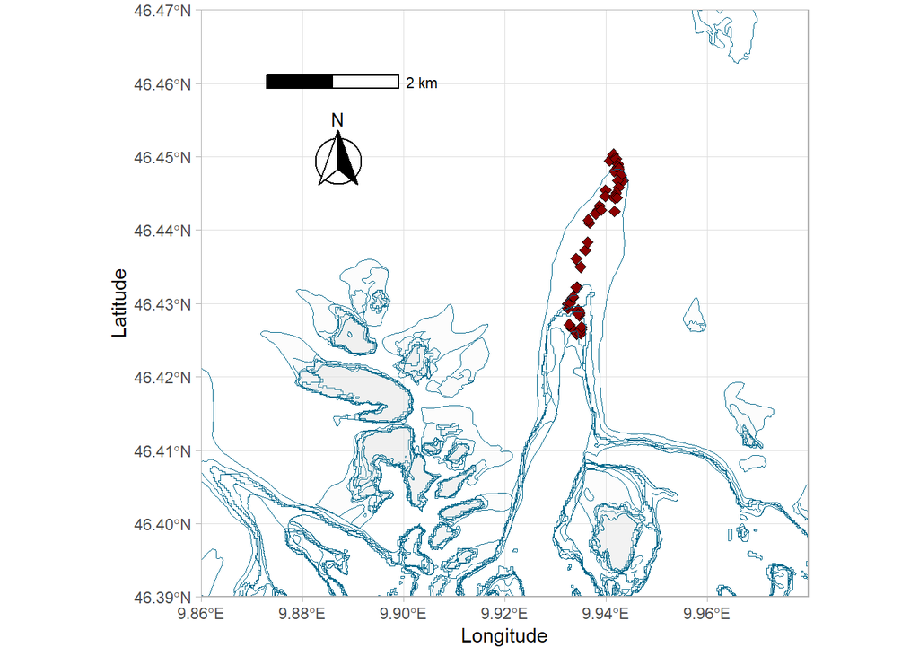

```r
##Loading additional package for GIS visualization

library(sf) #for ploting shape and coordenates
library(ggplot2)
library(ggspatial) # for annotating maps

## Loading GIS data - glaciers shape - downloaded on GLIMS (https://www.glims.org/maps/glims)
   # I did not wanted to bother Dr.Temme again, so insted of maping the 1850 extent, I used the full glacier data I found online on the GLIMS website.

GLIMSglaciers<-st_read("glims_download_15633/glims_glaciers_polygons.shp")
dgeo <- st_as_sf(d, coords = c("Xdecimal", "Ydecimal"),crs = 4326, agr = "constant")

#Plotting Morteratsch study site
Morteratsch_plots <- ggplot(data = filter(dgeo,Site=="Morteratsch")) +
    geom_sf(data = filter(dgeo,Site=="Morteratsch"), size = 2, shape = 23, fill = "darkred") +
    geom_sf(data = GLIMSglaciers, aes(), color="deepskyblue4", size = 0.2, alpha=0.1) +
    coord_sf(xlim = c(9.860000, 9.980000), ylim = c(46.39000, 46.47000), expand = FALSE)+
    theme_light() +
    labs(x="Longitude", y="Latitude")+
    annotation_scale(
    location = "tl", width_hint = 0.25,
    pad_x = unit(0.5, "in"),
    pad_y = unit(0.5, "in")) +
  annotation_north_arrow(
    location = "tl", which_north = "true",
    pad_x = unit(0.75, "in"), pad_y = unit(0.8, "in"),
    style = north_arrow_fancy_orienteering)
  #geom_text(data = filter(GLIMSglaciers, glac_name=="MORTERATSCH VADRET DA"), aes(X,Y,label = glac_name), size = 5)
Morteratsch_plots
```

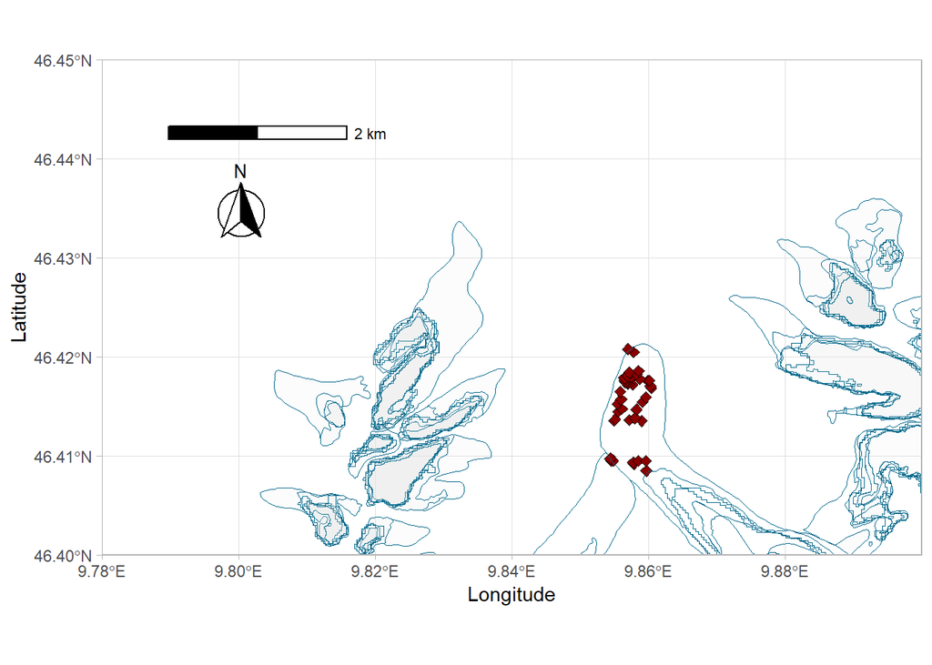

```r
#Tschierva study site
Tschierva_plots <- ggplot(data = filter(dgeo,Site=="Tschierva")) +
    geom_sf(data = filter(dgeo,Site=="Tschierva"), size = 2, shape = 23, fill = "darkred") +
    geom_sf(data = GLIMSglaciers, aes(), color="deepskyblue4", size = 0.2, alpha=0.1) +
    coord_sf(xlim = c(9.78000, 9.90000), ylim = c(46.40000, 46.45000), expand = FALSE)+
    theme_light() +
    labs(x="Longitude", y="Latitude")+
    annotation_scale(
    location = "tl", width_hint = 0.25,
    pad_x = unit(0.5, "in"),
    pad_y = unit(0.5, "in")) +
  annotation_north_arrow(
    location = "tl", which_north = "true",
    pad_x = unit(0.75, "in"), pad_y = unit(0.8, "in"),
    style = north_arrow_fancy_orienteering)
Tschierva_plots
```

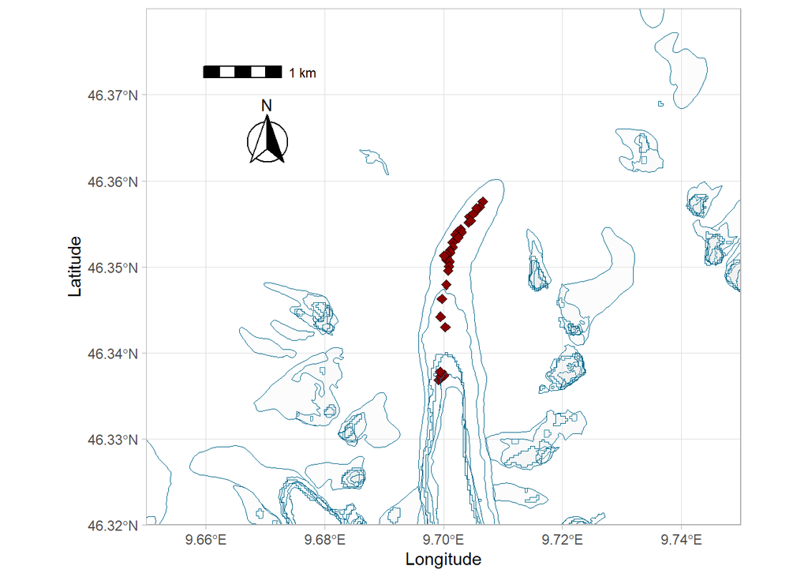

```r
#Plotting Forno study site
Forno_plots <- ggplot(data = filter(dgeo,Site=="Forno")) +
    geom_sf(data = filter(dgeo,Site=="Forno"), size = 2, shape = 23, fill = "darkred") +
    geom_sf(data = GLIMSglaciers, aes(), color="deepskyblue4", size = 0.2, alpha=0.1) +
    coord_sf(xlim = c(9.65000, 9.75000), ylim = c(46.32000, 46.38000), expand = FALSE)+
    theme_light() +
    labs(x="Longitude", y="Latitude")+
    annotation_scale(
    location = "tl", width_hint = 0.25,
    pad_x = unit(0.5, "in"),
    pad_y = unit(0.5, "in")) +
  annotation_north_arrow(
    location = "tl", which_north = "true",
    pad_x = unit(0.75, "in"), pad_y = unit(0.8, "in"),
    style = north_arrow_fancy_orienteering)
Forno_plots
```

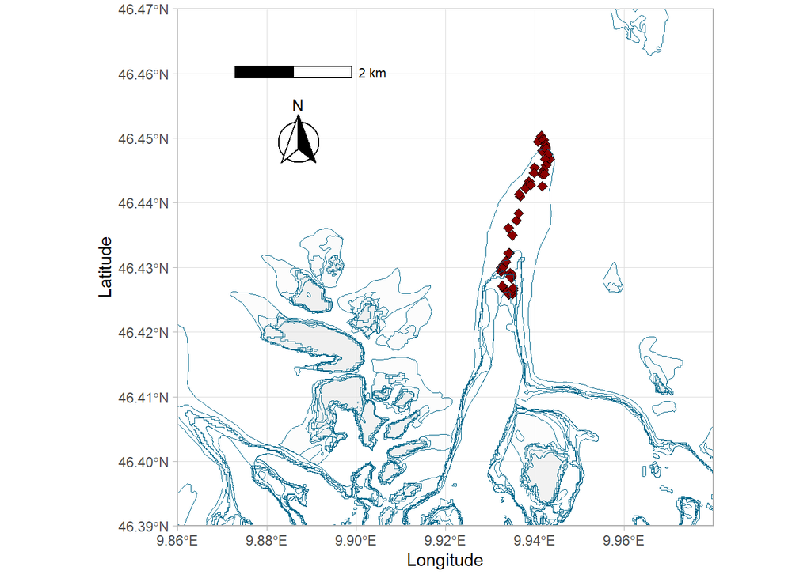

```r
par(mfrow=c(3,1))
Morteratsch_plots
```

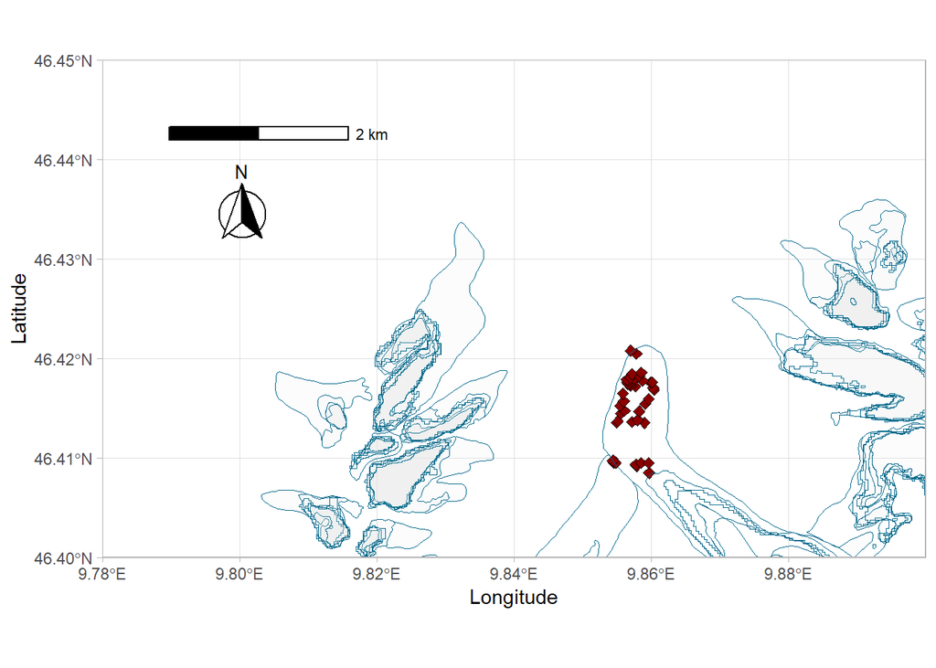

```r
Tschierva_plots
```

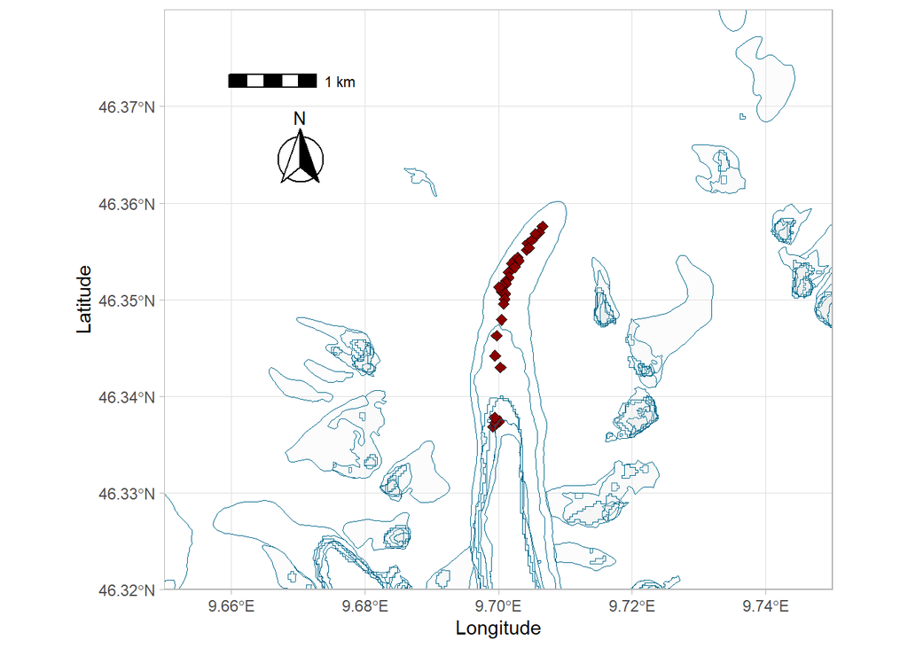

```r
Forno_plots
```

```r
#gridExtra::grid.arrange(Morteratsch_plots,Tschierva_plots,Forno_plots, ncol=3)
```

Previous to this, I had the objective to use a Google map background, as in Figure 3 of the paper. I tried two methods, using the package ggmap, and the package leaflet. For {ggmap} and get_googlemap(), I learnt that now we need credit on Google cloud to get the necessary API Key. I could have use some of the free credits, but since they ask credit card information and etc. (in case we over passed the number of free credit allowed) I did not want to do it and I look for another method. Regarding {leaflet} and {sp}, I got some fun interactive maps but it was not what I was looking for. Also I was not able to add the plot points to it.

```r
library(sp)
library(leaflet)
df <- data.frame(longitude = runif(10, 9.699000, 9.943500),
                 latitude = runif(10, 46.33000, 46.45050))

coordinates(df) <- ~longitude+latitude
leaflet(df) %>% addCircleMarkers() %>% addTiles()
```

[interactive chart not shown]

### 1. Summary statistic

- Table II presents the summary statistics for some numerical attributes of the soils for every pro-glacial valley for the stable and fluvial zones.

```r
## computing summary statistic for the 5 variables of interest: pH, SSD, Vegetation cover, Soil Stoniness and Surface Stoniness, for all observations, and for each site depending of the geomorphological zone (Stable or Fluvial)

 #reordering Site to read results with the same order than in the paper (easier to check on data values)

d$Site<-factor(d$Site,levels = c("Forno","Tschierva","Morteratsch"))

Summary<-d%>%
  select(Site, geomorph_zone,pH_field, stoniness_soil, stoniness_surf, veg_cover,SSD)%>%
  group_by(Site, geomorph_zone)%>%
  filter(geomorph_zone=="fluvial"| geomorph_zone== "development")%>%
  summarise(across(c("pH_field", "stoniness_soil", "stoniness_surf", "veg_cover","SSD"),list(Mean=mean, SD=sd),na.rm=TRUE))
Summary
```

```
## # A tibble: 6 x 12
## # Groups:   Site [3]
##   Site        geomorph_zone pH_field_Mean pH_field_SD stoniness_soil_Mean
##   <fct>       <chr>                 <dbl>       <dbl>               <dbl>
## 1 Forno       development            5.94       0.692                37.5
## 2 Forno       fluvial                7          0                    26.2
## 3 Tschierva   development            6.34       0.812                23.1
## 4 Tschierva   fluvial                6.61       0.987                35.7
## 5 Morteratsch development            5.85       0.924                31.9
## 6 Morteratsch fluvial                7          0                    16.7
## # ... with 7 more variables: stoniness_soil_SD <dbl>,
## #   stoniness_surf_Mean <dbl>, stoniness_surf_SD <dbl>, veg_cover_Mean <dbl>,
## #   veg_cover_SD <dbl>, SSD_Mean <dbl>, SSD_SD <dbl>
```

```r
SummaryAll<-d%>%
  summarise(across(c("pH_field", "stoniness_soil", "stoniness_surf", "veg_cover","SSD"),list(Mean=mean, SD=sd),na.rm=TRUE)) ### !!!!!!!! Need to add a function COUNT that have a na.rm argument
SummaryAll
```

```
## # A tibble: 1 x 10
##   pH_field_Mean pH_field_SD stoniness_soil_M~ stoniness_soil_SD stoniness_surf_~
##           <dbl>       <dbl>             <dbl>             <dbl>            <dbl>
## 1          6.08       0.890              30.1              16.9             55.2
## # ... with 5 more variables: stoniness_surf_SD <dbl>, veg_cover_Mean <dbl>,
## #   veg_cover_SD <dbl>, SSD_Mean <dbl>, SSD_SD <dbl>
```

```r
# Count the number of observation total and per geomorph zone

Count <- d %>%  group_by(Site, geomorph_zone) %>% summarize(n=n())
CountAll<-d %>%filter(geomorph_zone=="fluvial"| geomorph_zone== "development")%>% summarize(n=n())

#joining tables
Summaries<-full_join(SummaryAll,Summary, by=NULL)
Counts<-full_join( CountAll,Count,by=NULL)
table <- left_join(Summaries,Counts,by=(c("Site","geomorph_zone")))

table %>%rename(zone='geomorph_zone')%>%
  rename(pH_mean="pH_field_Mean")%>%
  rename(pH_sd="pH_field_SD")%>%
  rename(Number_observations="n")->table

table$Number_observations<-as.factor(table$Number_observations) # needed to transform Number of Obs as a factor if no apllying the transpose t() function will round it at 0.1


table<-table%>%as.data.frame()%>% dplyr::select(Number_observations, pH_mean, pH_sd, SSD_Mean, SSD_SD,veg_cover_Mean,veg_cover_SD, stoniness_soil_Mean, stoniness_soil_SD, stoniness_surf_Mean, stoniness_surf_SD)%>%mutate_if(is.numeric, round, digits=1)%>%t()

#Final table
kableExtra::kbl(table) %>%
  kable_classic()%>%
  kable_paper("striped", full_width = F) %>%
  add_header_above(c("Zone"=1,"All" ,"Stable" = 1, "Fluvial" = 1,"Stable" = 1, "Fluvial" =1 ,"Stable" = 1, "Fluvial" = 1),bold=T) %>%
  add_header_above(c("Pro-glacial area " = 1, "All", "Forno" = 2, "Tschierva" = 2, "Morteratsch" = 2),bold=T)%>%
   pack_rows("Variables",2 ,3)
```

| Pro-glacial area Zone | All | Forno Stable | Forno Fluvial | Tschierva Stable | Tschierva Fluvial | Morteratsch Stable | Morteratsch Fluvial |
| --- | --- | --- | --- | --- | --- | --- | --- |
| Number_observations | 111 | 25 | 4 | 29 | 7 | 43 | 3 |
| **Variables** |  |  |  |  |  |  |  |
| pH_mean | 6.1 | 5.9 | 7.0 | 6.3 | 6.6 | 5.8 | 7.0 |
| pH_sd | 0.9 | 0.7 | 0.0 | 0.8 | 1.0 | 0.9 | 0.0 |
| SSD_Mean | 2.0 | 2.5 | 2.1 | 2.0 | 0.4 | 1.9 | 0.0 |
| SSD_SD | 2.7 | 2.9 | 2.9 | 1.3 | 0.9 | 3.1 | 0.0 |
| veg_cover_Mean | 38.5 | 30.5 | 36.2 | 46.0 | 42.9 | 39.8 | 0.7 |
| veg_cover_SD | 30.8 | 26.0 | 27.5 | 25.7 | 38.3 | 33.8 | 1.2 |
| stoniness_soil_Mean | 30.1 | 37.5 | 26.2 | 23.1 | 35.7 | 31.9 | 16.7 |
| stoniness_soil_SD | 16.9 | 19.5 | 16.0 | 11.8 | 19.2 | 16.3 | 14.4 |
| stoniness_surf_Mean | 55.2 | 63.7 | 48.8 | 48.6 | 59.3 | 56.6 | 37.0 |
| stoniness_surf_SD | 29.8 | 27.7 | 31.7 | 26.1 | 36.8 | 30.9 | 31.6 |

- Paper’s method: The T-test was used to test for differences in mean soil properties between the different zones in pro-glacial areas. They tested for pH (pH_field), Depth of soil formation (“SSD” = significant soil depth),Vegetation cover (“veg_cover”), Soil Stoniness (“stoniness_soil”), and Surface stoniness (“stoniness_surf”). The standard deviation was also computed.

```r
# Computing the P-Value of the T-test

d<-d%>%filter(geomorph_zone=="fluvial"|geomorph_zone=="development")%>%filter(pH_field!='na')


Table_p_values<-tibble(Site=character(),
                variable=character(),
                p=numeric())

Site<-unique(d$Site)

df<-d%>%select(pH_field, veg_cover, stoniness_soil, stoniness_surf)

Site<-unique(d$Site)
for (i in Site){
   for (j in names(df)){
     #print(j)
 temp<-d %>% filter(Site==i)%>%select(j, geomorph_zone)
 print(nrow(temp))
 p<-t.test(temp[[j]]~temp$geomorph_zone)$p.value
 #print(p)
 r<- tibble(Site=i,variable=j,p=p)
 Table_p_values<-bind_rows(Table_p_values,r)
}}
```

```
## Note: Using an external vector in selections is ambiguous.
## i Use `all_of(j)` instead of `j` to silence this message.
## i See <https://tidyselect.r-lib.org/reference/faq-external-vector.html>.
```

```
## [1] 46
## [1] 46
## [1] 46
## [1] 46
## [1] 36
## [1] 36
## [1] 36
## [1] 36
## [1] 28
## [1] 28
## [1] 28
## [1] 28
```

```r
Table_p_values
```

```
## # A tibble: 12 x 3
##    Site        variable              p
##    <chr>       <chr>             <dbl>
##  1 Morteratsch pH_field       3.28e-10
##  2 Morteratsch veg_cover      2.20e- 9
##  3 Morteratsch stoniness_soil 2.02e- 1
##  4 Morteratsch stoniness_surf 3.95e- 1
##  5 Tschierva   pH_field       5.17e- 1
##  6 Tschierva   veg_cover      8.40e- 1
##  7 Tschierva   stoniness_soil 1.40e- 1
##  8 Tschierva   stoniness_surf 4.91e- 1
##  9 Forno       pH_field       1.28e- 7
## 10 Forno       veg_cover      7.17e- 1
## 11 Forno       stoniness_soil 3.66e- 1
## 12 Forno       stoniness_surf 4.68e- 1
```

```r
Table_p_values<-Table_p_values%>%select(variable,p)%>%
 rename('p-value (stable=fluvial)' ="p")

kableExtra::kbl(Table_p_values) %>%
  kable_classic()%>%
  kable_paper("striped", full_width = F) %>%
  pack_rows("Morteratsch",1 ,4)%>%
  pack_rows("Tschierva",5 ,8)%>%
  pack_rows("Forno",9 ,12)
```

| variable | p-value (stable=fluvial) |
| --- | --- |
| **Morteratsch** |  |
| pH_field | 0.0000000 |
| veg_cover | 0.0000000 |
| stoniness_soil | 0.2017459 |
| stoniness_surf | 0.3951365 |
| **Tschierva** |  |
| pH_field | 0.5166745 |
| veg_cover | 0.8404692 |
| stoniness_soil | 0.1400032 |
| stoniness_surf | 0.4909004 |
| **Forno** |  |
| pH_field | 0.0000001 |
| veg_cover | 0.7165679 |
| stoniness_soil | 0.3663590 |
| stoniness_surf | 0.4681886 |

### 2. Descriptive analysis - Visualization of Figure 5: pH Values as a function of time since glacial retreat for observations in the fluvial and stable zones, with potential debris flows in the stable zone separated from the rest of that zone.

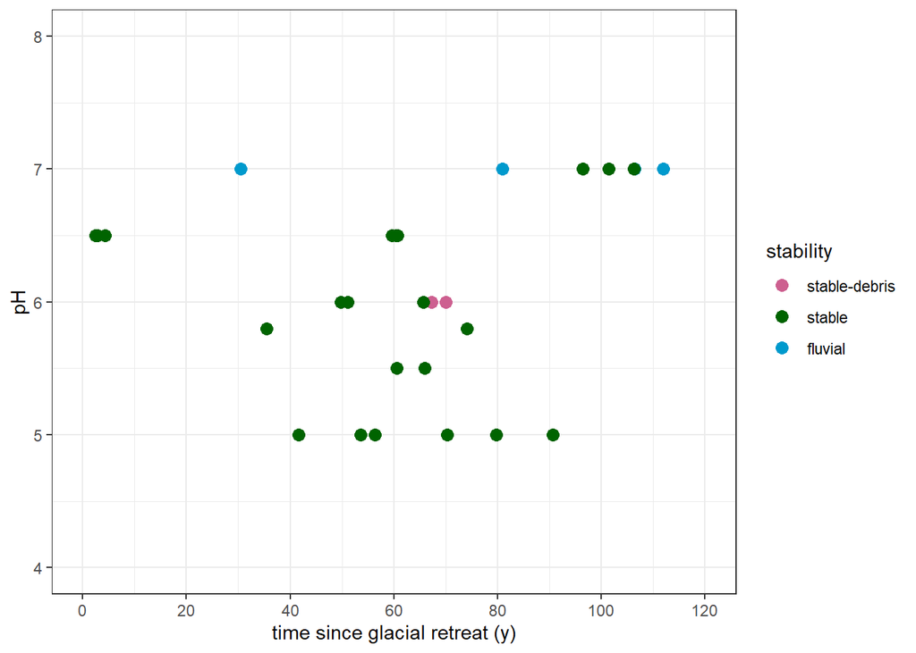

```r
# Creating a new data set to remove "slope" and "none" values of the [geomorh_zone variable]
d_stability_Forno<-d%>%filter(Site=="Forno")%>% ###COMMENTS : It took me a very long while to understand the graph was only including the Forno data set!
  filter(geomorph_zone!="none")%>%
  filter(geomorph_zone!="slope")

# Creating a new variable call stability
d_stability_Forno<-d_stability_Forno%>%
  mutate(stability=case_when(
    geomorph_zone=="development" & potential_dist=="debris flow"~"stable-debris",
    geomorph_zone=="development"~"stable",
    geomorph_zone=="fluvial"~"fluvial"))

#View(d_stability_Forno)

# Reordering the stability variable
d_stability_Forno$stability<-factor(d_stability_Forno$stability,levels=c("stable-debris", "stable","fluvial"))

# Plotting pH in function of time since glacier retreat , and grouping by stability

pH_time<-ggplot(d_stability_Forno, aes(y=pH_field, x=realTSR, color=stability)) +
  geom_point(aes(color=stability), size=3) +
  scale_color_manual(values=c('hotpink3','darkgreen','deepskyblue3'))+
  theme_bw()+
  coord_cartesian(xlim=c(0,120),ylim=c(4,8)) +
  scale_x_continuous(breaks = c(0, 20, 40, 60, 80, 100,120))+
  labs(x="time since glacial retreat (y)", y="pH") +
  theme_bw()
pH_time
```

* On this first version of the graph we observe three differences with the original graph of the paper. One fluvial point is missing from the data base and one points (top right) appear as stable and should be a fluvial point, as weel its neighboor that is also stable and should be stable-debris.

Below we look at the same graph but using different shapes to draw the pH values. Here, we notice that F27 and F29 where superposed. The blue fluvial F27 was hidden by the green stable 29.

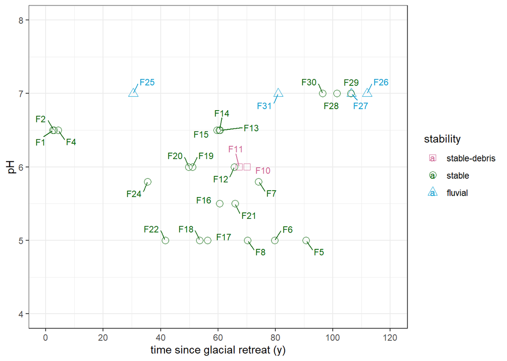

```r
pH_time<-ggplot(d_stability_Forno, aes(y=pH_field, x=realTSR, color=stability)) +
  geom_point(aes(shape=stability,color=stability), size=3) +
  scale_color_manual(values=c('hotpink3','darkgreen','deepskyblue3'))+
  scale_shape_manual(values=c(22,21,24))+
  theme_bw()+
  coord_cartesian(xlim=c(0,120),ylim=c(4,8)) +
  scale_x_continuous(breaks = c(0, 20, 40, 60, 80, 100,120))+
  labs(x="time since glacial retreat (y)", y="pH") +
  ggrepel::geom_text_repel(data=d_stability_Forno,mapping= aes(label=d_stability_Forno$point),size=3,box.padding=unit(0.5,"lines"))+
  theme_bw()
pH_time
```

Similar conclusion are observed using geom_jitter(), and playing with the transparency alpha:

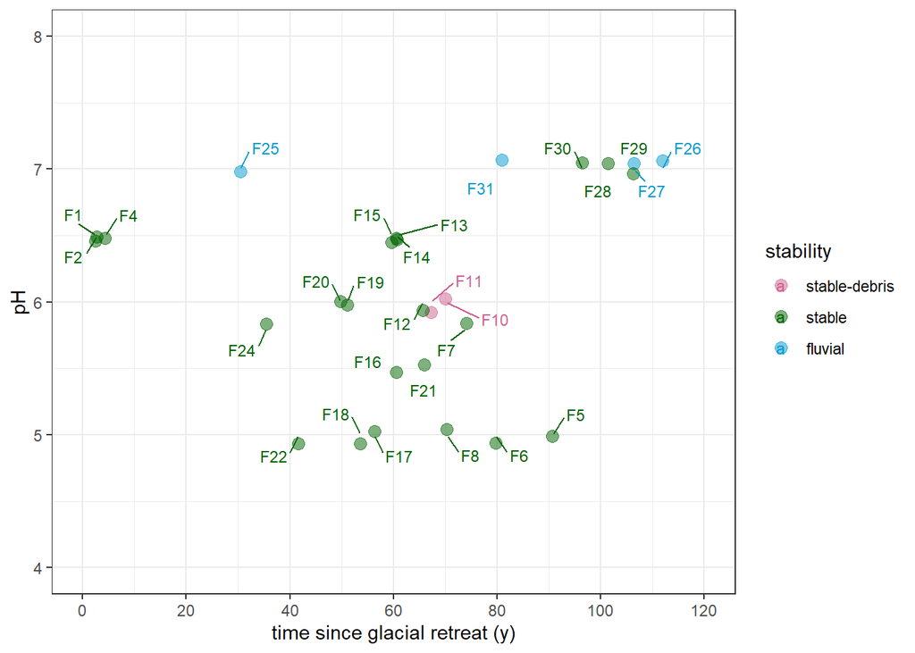

```r
pH_time<-ggplot(d_stability_Forno, aes(y=pH_field, x=realTSR, color=stability)) +
  geom_jitter(aes(color=stability), size=3, alpha=0.5) +
  scale_color_manual(values=c('hotpink3','darkgreen','deepskyblue3'))+
  theme_bw()+
  coord_cartesian(xlim=c(0,120),ylim=c(4,8)) +
  scale_x_continuous(breaks = c(0, 20, 40, 60, 80, 100,120))+
  labs(x="time since glacial retreat (y)", y="pH") +
  ggrepel::geom_text_repel(data=d_stability_Forno,mapping= aes(label=d_stability_Forno$point),size=3,box.padding=unit(0.5,"lines"))+
  theme_bw()
pH_time
```

However, there is still a difference according F28 that appear as stable-debris (red) on the original figure in Figure 5, and as stable (green) in our graph. And one other fluvial point between F24 and F22 is missing.

Below the same code is run with this alternative data set called “All Export”.

This disagreement might be what also cause the different results observed in the Summary table.But we have the same count of observation, so this is still questionable.

Now only an error with F23 which appear with “slope” in the both dataset, but as “fluvial” in the graph of the paper.

```r
f1<-"https://raw.githubusercontent.com/anaiszimmer/Data_Analysis_Replication_Assignment/main/All_export.csv"
All_export <- read_csv(f1, col_names = TRUE)
```

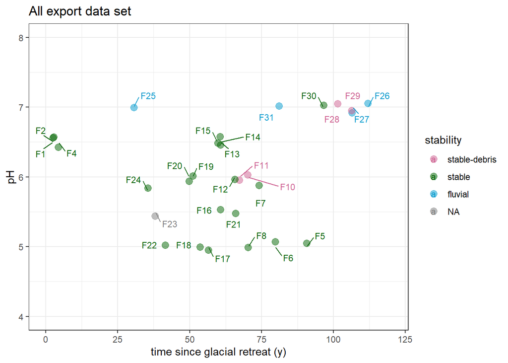

```r
d_stability_Forno2<-All_export%>%
  filter(Site=="Forno")%>%
  mutate(stability=case_when(
    geomorph_zone=="development" & potential_dist=="debris flow"~"stable-debris",
    geomorph_zone=="development"~"stable",
    geomorph_zone=="fluvial"~"fluvial"))%>%
  filter(pH_field!="na")%>%
  filter(geomorph_zone!="na")

d_stability_Forno2$stability<-factor(d_stability_Forno2$stability,levels=c("stable-debris", "stable","fluvial"))

pH_time2<-ggplot(d_stability_Forno2, aes(y=pH_field, x=realTSR, color=stability)) +
  geom_jitter(aes(color=stability), size=3, alpha=0.5) +
  scale_color_manual(values=c('hotpink3','darkgreen','deepskyblue3'))+
  theme_bw()+
  coord_cartesian(xlim=c(0,120),ylim=c(4,8)) +
  #scale_x_continuous(breaks = c(0, 20, 40, 60, 80, 100,120))+
  labs(title="All export data set", x="time since glacial retreat (y)", y="pH") +
  ggrepel::geom_text_repel(data=d_stability_Forno2,mapping= aes(label=d_stability_Forno2$point),size=3,box.padding=unit(0.5,"lines"))+
  theme_bw()
pH_time2
```

### 3. Linear model

- Table III. Strength (r) and significance (p (r = 0)) of the correlation between the time since glacial retreat and soil properties, for the stable zone of the pro-glacial areas in all three valleys

```r
f <- "https://raw.githubusercontent.com/anaiszimmer/Data_Analysis_Replication_Assignment/main/Sites.csv"
d <- read_csv(f, col_names = TRUE)
head(d)
```

```
## # A tibble: 6 x 30
##   Site        point geomorph_zone potential_dist   TSR realTSR Ydecimal Xdecimal
##   <chr>       <chr> <chr>         <chr>          <dbl>   <dbl>    <dbl>    <dbl>
## 1 Morteratsch M28   none          none            1857     154     46.4     9.94
## 2 Morteratsch M40   none          none            1850     161     46.5     9.94
## 3 Morteratsch M41   none          none            1850     161     46.4     9.94
## 4 Morteratsch M42   none          none            1850     161     46.4     9.94
## 5 Morteratsch M43   none          none            1850     161     46.4     9.94
## 6 Morteratsch M44   none          none            1850     161     46.4     9.94
## # ... with 22 more variables: rad_raster <dbl>, altitude_m <dbl>, slope <dbl>,
## #   logslope <dbl>, aspect <dbl>, E <dbl>, N <dbl>, plan_curvature <chr>,
## #   plan_num <dbl>, profile_curv <chr>, profile_num <dbl>, curvature_DEM <dbl>,
## #   stoniness_surf <dbl>, stoniness_soil <dbl>, veg_type <lgl>,
## #   veg_cover <dbl>, texture_class <chr>, sorting <chr>, sand_fraction <chr>,
## #   pH_field <dbl>, soil_class <chr>, SSD <dbl>
```

```r
#View(d)

 # Creating a new data set to remove "slope" and "none" values of the [geomorh_zone variable]
d_stability<-d%>%
  filter(geomorph_zone!="none")%>%
  filter(geomorph_zone!="slope")


 # Creating a new variable call stability
d_stability<-d_stability%>%
  mutate(stability=case_when(
    geomorph_zone=="development" & potential_dist=="debris flow"~"stable-debris",
    geomorph_zone=="development"~"stable",
    geomorph_zone=="fluvial"~"fluvial"))

d_stability$potential_dist[is.na(d_stability$potential_dist)]<-"none"


### Pearson Correlation

#Subset stable zone only
dcor<-d_stability%>%filter(stability=="stable")%>%filter(potential_dist=="none")%>%select(Site,pH_field, SSD,veg_cover, stoniness_soil, stoniness_surf, realTSR)%>%filter(!is.na(pH_field))

dcor$Site<-factor(dcor$Site,levels = c("Forno","Tschierva","Morteratsch"))
# dcor<-d%>%filter(geomorph_zone=="development")%>%filter(potential_dist!="debris flow")%>% select(Site,pH_field, SSD,veg_cover, stoniness_soil, stoniness_surf, realTSR)%>%filter(!is.na(pH_field))
# view(dcor)

Site<-unique(dcor$Site)

dvar<-dcor%>%select(pH_field,SSD, veg_cover, stoniness_soil, stoniness_surf)



#Empty table for results
Table_pearson<-tibble(Site=character(),
                       variable=character(),
                       r=numeric(),
                       p=numeric())

for (i in Site){
  for (j in names(dvar)){
    #print(j)
    temp<-dcor %>% filter(Site==i)
    print(nrow(temp))
    p<-cor.test(temp[[j]],temp$realTSR,method="pearson")$p.value
    rho<-cor.test(temp[[j]],temp$realTSR,method="pearson")$estimate
    #print(p)
    results<- tibble(Site=i,variable=j,r=rho,p=p)
    Table_pearson<-bind_rows(Table_pearson,results)
  }}
```

```
## [1] 31
## [1] 31
## [1] 31
## [1] 31
## [1] 31
## [1] 29
## [1] 29
## [1] 29
## [1] 29
## [1] 29
## [1] 22
## [1] 22
## [1] 22
## [1] 22
## [1] 22
```

```r
Table_pearson
```

```
## # A tibble: 15 x 4
##    Site        variable              r            p
##    <chr>       <chr>             <dbl>        <dbl>
##  1 Morteratsch pH_field       -0.826   0.0000000109
##  2 Morteratsch SSD             0.599   0.000375
##  3 Morteratsch veg_cover       0.754   0.000000966
##  4 Morteratsch stoniness_soil -0.465   0.00841
##  5 Morteratsch stoniness_surf -0.663   0.0000479
##  6 Tschierva   pH_field       -0.537   0.00269
##  7 Tschierva   SSD             0.323   0.0874
##  8 Tschierva   veg_cover       0.0753  0.698
##  9 Tschierva   stoniness_soil  0.277   0.146
## 10 Tschierva   stoniness_surf  0.122   0.528
## 11 Forno       pH_field        0.00908 0.968
## 12 Forno       SSD             0.453   0.0341
## 13 Forno       veg_cover       0.568   0.00586
## 14 Forno       stoniness_soil -0.532   0.0109
## 15 Forno       stoniness_surf -0.185   0.410
```

```r
Table_pearson<-Table_pearson%>%select(variable,r,p) #remove the column site for nicer table in kableExtra
(count <- dcor %>%  group_by(Site) %>% summarize(n=n()))    # Count the number of observation total and per geomorph zone
```

```
## # A tibble: 3 x 2
##   Site            n
##   <fct>       <int>
## 1 Forno          22
## 2 Tschierva      29
## 3 Morteratsch    31
```

```r
  kableExtra::kbl(Table_pearson) %>%
  kable_classic()%>%
  kable_paper("striped", full_width = F) %>%
  pack_rows("Morteratsch  n=31",1 ,5)%>%
  pack_rows("Tschierva  n=29",6 ,10)%>%
  pack_rows("Forno  n=22",11 ,15)
```

| variable | r | p |
| --- | --- | --- |
| **Morteratsch n=31** |  |  |
| pH_field | -0.8256288 | 0.0000000 |
| SSD | 0.5986016 | 0.0003746 |
| veg_cover | 0.7540649 | 0.0000010 |
| stoniness_soil | -0.4648941 | 0.0084124 |
| stoniness_surf | -0.6631361 | 0.0000479 |
| **Tschierva n=29** |  |  |
| pH_field | -0.5366498 | 0.0026886 |
| SSD | 0.3230808 | 0.0873581 |
| veg_cover | 0.0752556 | 0.6980248 |
| stoniness_soil | 0.2768002 | 0.1460503 |
| stoniness_surf | 0.1222289 | 0.5276191 |
| **Forno n=22** |  |  |
| pH_field | 0.0090849 | 0.9679933 |
| SSD | 0.4533952 | 0.0340708 |
| veg_cover | 0.5676603 | 0.0058580 |
| stoniness_soil | -0.5317923 | 0.0108568 |
| stoniness_surf | -0.1849270 | 0.4099991 |

The results obtained are very different than the one of Table III. The sign of r is most of the time the same than show in Table III (except for pH at Forno). At the Forno, the authors used 20 points, I found 22 points in the table that have stable carracteristic and no NA values. It seems two points have be deleted from the data set. I cannot find which ones.